# Modeling & Simulating Hourly Electricity

Note: Regression trees are known to be weak learners which can very easily overfit the data. While we do not address this issue in this demo, you may want to use out-of-sample cross-validation to prune the tree to balance accuracy of a training and test set. This can be done manually by using a separate subset of the data to build the model and a different subset to test its accuracy or by using a function such as CROSSVAL in Statistics Toolbox

Table of Contents

Import Data Plot Prices Create Predictor and Response timetable Build Regression Tree Model Compute & Visualize Model Performance Analyze Serial Correlation in Residuals Modeling the Stochastic Component with a seasonal AR model Analyze Residuals of Regression for Serial Correlation Summary of model Simulate model

## Import Data

```matlab
clear
load Data\ngPrices.mat
load Data\elecPrices
tail(ngPrices)
```

ans = 8×5 timetable

|  | RNGWHHDd | RNGC1d | RNGC2d | RNGC3d | RNGC4d |
| --- | --- | --- | --- | --- | --- |
| 1 04-Jan-2019 00:00:00 | 2.8000 | 3.0440 | 2.9050 | 2.6880 | 2.6600 |
| 2 07-Jan-2019 00:00:00 | 2.7400 | 2.9440 | 2.8470 | 2.6770 | 2.6620 |
| 3 08-Jan-2019 00:00:00 | 2.8900 | 2.9670 | 2.8350 | 2.6950 | 2.6830 |
| 4 09-Jan-2019 00:00:00 | 2.9200 | 2.9840 | 2.8400 | 2.7060 | 2.6960 |
| 5 10-Jan-2019 00:00:00 | 2.9500 | 2.9690 | 2.8130 | 2.7060 | 2.6980 |
| 6 11-Jan-2019 00:00:00 | 2.9500 | 3.0990 | 2.9450 | 2.7690 | 2.7470 |
| 7 14-Jan-2019 00:00:00 | 3.3600 | 3.5910 | 3.2890 | 2.9050 | 2.8620 |
| 8 15-Jan-2019 00:00:00 | NaN | 3.5010 | 3.2490 | 2.8460 | 2.8040 |

```matlab
tail(elecPrices)
```

ans = 8×16 timetable

|  | Hr_End | DA_Demand | RT_Demand | DA_LMP | DA_EC | DA_CC | DA_MLC | RT_LMP | RT_EC | RT_CC | RT_MLC | Dry_Bulb | Dew_Point | System_Load | Reg_Capacity_Price | Reg_Service_Price |
| --- | --- | --- | --- | --- | --- | --- | --- | --- | --- | --- | --- | --- | --- | --- | --- | --- |
| 1 11/30/2018 | 17 | 15691 | 1.5901e+04 | 79.9000 | 80.5900 | 0 | -0.6900 | 82.7900 | 83.1800 | 0 | -0.3900 | 36 | 29 | 16091 | 22.2950 | 0.0833 |
| 2 11/30/2018 | 18 | 1.6240e+04 | 1.6409e+04 | 90.3000 | 91.1600 | 0 | -0.8600 | 87.0200 | 87.4700 | 0 | -0.4500 | 35 | 30 | 16539 | 59.6908 | 0.2367 |
| 3 11/30/2018 | 19 | 1.5545e+04 | 1.6148e+04 | 78.2700 | 78.9500 | 0 | -0.6800 | 97.7900 | 98.2200 | 0 | -0.4300 | 35 | 30 | 16243 | 65.5925 | 0.2958 |
| 4 11/30/2018 | 20 | 1.4776e+04 | 1.5689e+04 | 63.1400 | 63.3300 | 0 | -0.1900 | 103.2000 | 103.4000 | 0 | -0.2000 | 35 | 30 | 15764 | 77.8833 | 0.4833 |
| 5 11/30/2018 | 21 | 1.4612e+04 | 1.5120e+04 | 61.1700 | 61.3500 | 0 | -0.1800 | 82.6900 | 82.7300 | 0 | -0.0400 | 35 | 30 | 15183 | 61.0133 | 0.0508 |
| 6 11/30/2018 | 22 | 1.4009e+04 | 1.4333e+04 | 53.4000 | 53.4900 | 0 | -0.0900 | 60.7000 | 60.6800 | 0 | 0.0200 | 34 | 29 | 14395 | 39.7450 | 0.0100 |
| 7 11/30/2018 | 23 | 1.2850e+04 | 1.3337e+04 | 46.7100 | 46.7600 | 0 | -0.0500 | 54.5000 | 54.4000 | 0 | 0.1000 | 34 | 29 | 13401 | 104.4100 | 0.4183 |
| 8 11/30/2018 | 24 | 1.1669e+04 | 1.2337e+04 | 46.8100 | 46.8800 | 0 | -0.0700 | 50.7400 | 50.6400 | 0 | 0.1000 | 33 | 29 | 12371 | 28.7900 | 0.2958 |

```matlab
vars2keep = {'Hr_End','DA_LMP','Dry_Bulb'}
```

vars2keep = 1×3 cell array

{'Hr_End'} {'DA_LMP'} {'Dry_Bulb'}

```matlab
T = elecPrices(:,vars2keep);
tail(T)
```

ans = 8×3 timetable

|  | Hr_End | DA_LMP | Dry_Bulb |
| --- | --- | --- | --- |
| 1 11/30/2018 | 17 | 79.9000 | 36 |
| 2 11/30/2018 | 18 | 90.3000 | 35 |
| 3 11/30/2018 | 19 | 78.2700 | 35 |
| 4 11/30/2018 | 20 | 63.1400 | 35 |
| 5 11/30/2018 | 21 | 61.1700 | 35 |
| 6 11/30/2018 | 22 | 53.4000 | 34 |
| 7 11/30/2018 | 23 | 46.7100 | 34 |
| 8 11/30/2018 | 24 | 46.8100 | 33 |

There are 13 days with 0 local marginal pricing of electricity, this is the daylights savings time change effect on the data. We fill these with the prior hours price.

```matlab
daylightIndx = T.DA_LMP == 0;
sum(daylightIndx)
```

ans = 13

```matlab
T.DA_LMP(daylightIndx) = T.DA_LMP(find(daylightIndx)-1);
```

Also import a list of local holidays that span the dataset. One can also use Financial Toolbox functions like HOLIDAYS, ISBUSDAY etc. to automatically generate holidays within the time range. We use holidays for the date range in our date set.

```matlab
hdays = holidays(min(T.Date),max(T.Date));
disp('Sample Holidays'); disp(hdays(1:20))
```

Sample Holidays 1/17/2011 2/21/2011 4/22/2011 5/30/2011 7/4/2011 9/5/2011 11/24/2011 12/26/2011 1/2/2012 1/16/2012 2/20/2012 4/6/2012 5/28/2012 7/4/2012 9/3/2012 10/29/2012 10/30/2012 11/22/2012 12/25/2012 1/1/2013

## Plot Prices

Create a visualization of the electricity prices from a macro and micro perspective

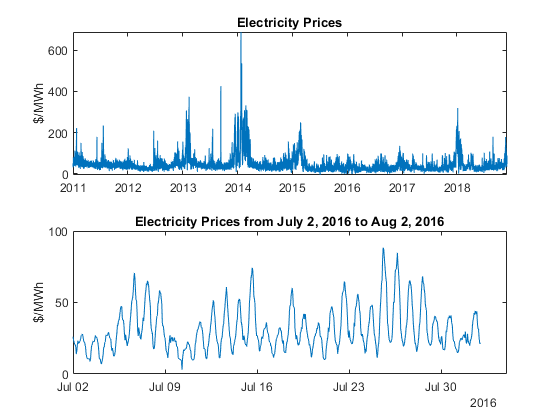

```matlab
subplot(2,1,1);
plot(T.Date, T.DA_LMP);
ylabel('$/MWh'); title('Electricity Prices');
subplot(2,1,2);
dateind = timerange('July 2, 2016','Aug 2, 2016');
plot(T.Date(dateind), T.DA_LMP(dateind))
ylabel('$/MWh'); title('Electricity Prices from July 2, 2016 to Aug 2, 2016');
```

## Create Predictor and Response timetable

The deterministic component of the model will take into account the relationship between electricity prices and natural gas prices, temperatures, hour of the day, day of the week and holidays. Therefore we generate a matrix of these predictors for every observation. These predictors include,

- Temperature & Deviation from seasonal average (the stochastic component of temperature)
- Hour of day, Day of Week, Month of year
- Category variable for workday or hoiday/weekend
- NG spot price, previous day price and previous week price

```matlab
% Temperature and deviation
tempModel = load('SavedModels\TemperatureModel.mat');
T.AveTemp = tempModel.m + tempModel.sinmodel(datenum(T.Date));
T.TempDeviation = T.Dry_Bulb - T.AveTemp;

% Hour of day is Hr_End, Month, and Calculate Day of Week and save as catgorical
T.Month = month(T.Date);
[~,T.WeekDay] = weekday(T.Date);
T.WeekDay = categorical(string(T.WeekDay));
T.WorkingDay = categorical(isbusday(T.Date,hdays),[1 0],{'Workday','Weekend/Holiday'});

% Spot fuel and prior spot fuel prices (syncronizing)
Pfuel = ngPrices(:,'RNGWHHDd');
Pfuel.Properties.VariableNames = {'Png'};

% keep consistent time with T
startTime = min(T.Date);
endTime = max(T.Date);
timeIdx = timerange(startTime,endTime,'closed');
Pfuel = Pfuel(timeIdx,:);

% retime to hourly with prieious pricing
Pfuel = retime(Pfuel,'hourly','linear');
PriorDay = lag(Pfuel);
PriorWk = lag(Pfuel,days(7));
Pfuel = synchronize(Pfuel,PriorDay);
Pfuel = synchronize(Pfuel,PriorWk);

% Join T and Pfuel and retime to hourly basis
T = synchronize(T,Pfuel);
tail(T)
```

ans = 8×11 timetable

|  | Hr_End | DA_LMP | Dry_Bulb | AveTemp | TempDeviation | Month | WeekDay | WorkingDay | Png_Pfuel | Png_PriorDay | Png |
| --- | --- | --- | --- | --- | --- | --- | --- | --- | --- | --- | --- |
| 1 11/30/2018 | 17 | 79.9000 | 36 | 34.1549 | 1.8451 | 11 | Fri | Workday | NaN | NaN | NaN |
| 2 11/30/2018 | 18 | 90.3000 | 35 | 34.1423 | 0.8577 | 11 | Fri | Workday | NaN | NaN | NaN |
| 3 11/30/2018 | 19 | 78.2700 | 35 | 34.1290 | 0.8710 | 11 | Fri | Workday | NaN | NaN | NaN |
| 4 11/30/2018 | 20 | 63.1400 | 35 | 34.1151 | 0.8849 | 11 | Fri | Workday | NaN | NaN | NaN |
| 5 11/30/2018 | 21 | 61.1700 | 35 | 34.1007 | 0.8993 | 11 | Fri | Workday | NaN | NaN | NaN |
| 6 11/30/2018 | 22 | 53.4000 | 34 | 34.0861 | -0.0861 | 11 | Fri | Workday | NaN | NaN | NaN |
| 7 11/30/2018 | 23 | 46.7100 | 34 | 34.0713 | -0.0713 | 11 | Fri | Workday | NaN | NaN | NaN |
| 8 11/30/2018 | 24 | 46.8100 | 33 | 34.0567 | -1.0567 | 11 | Fri | Workday | NaN | NaN | NaN |

## Build Regression Tree Model

Build a regression tree to model electricity prices given predictors. Visualize a highly-pruned small subset of the tree.

Note: Regression trees can easily overfit a training set. See the text at the start of this example for more information on how to avoid these pitfalls.

```matlab
X = timetable2table(T); % regressionLearner perfers to have tables.
X.NumericDate = datenum(X.Date); % add the date as a numeric value

% remove the missing year of data (2016)
X = rmmissing(X);

% Use this command to open the regression learner app and train a coarse
% tree:
% regressionLearner

% this is the model saved by generating code from the app:
[trainedModel, validationRMSE] = trainRegressionModel(X)
```

trainedModel = struct with fields:

predictFcn: @(x)treePredictFcn(predictorExtractionFcn(x)) RequiredVariables: {'Hr_End' 'Dry_Bulb' 'TempDeviation' 'Month' 'WeekDay' 'WorkingDay' 'Png_Pfuel' 'Png_PriorDay' 'Png'} RegressionTree: [1×1 RegressionTree] About: 'This struct is a trained model exported from Regression Learner R2018b.' HowToPredict: 'To make predictions on a new table, T, use: ↵ yfit = c.predictFcn(T) ↵replacing 'c' with the name of the variable that is this struct, e.g. 'trainedModel'. ↵ ↵The table, T, must contain the variables returned by: ↵ c.RequiredVariables ↵Variable formats (e.g. matrix/vector, datatype) must match the original training data. ↵Additional variables are ignored. ↵ ↵For more information, see How to predict using an exported model.'

validationRMSE = 18.1094

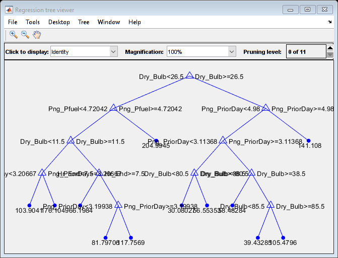

```matlab
figure
subsettree = prune(trainedModel.RegressionTree,'level',1050);
view(subsettree,'Mode','graph')
```

## Compute & Visualize Model Performance

Predict electricity prices using the model and compare them with the observed prices. The visualization function here is the same function used in the comparison of predicted and actual values for the Temperature model. The mean absolute error (MAE) is also displayed.

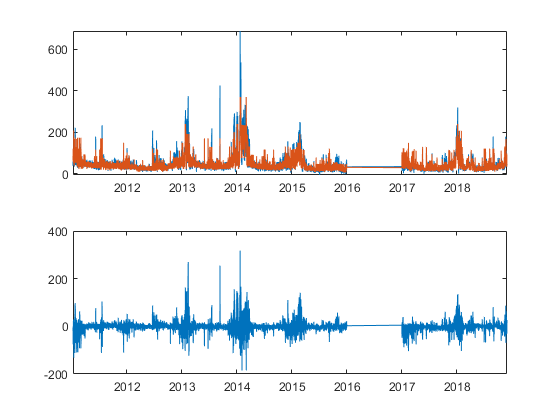

```matlab
X.pred = trainedModel.predictFcn(X);
res = X.DA_LMP - X.pred;

subplot(2,1,1)
plot(X.Date, [X.DA_LMP X.pred])
subplot(2,1,2)
plot(X.Date, res)
```

```matlab
disp(['Mean Absolute Error (in original units): $' num2str(mean(abs(res)))]);
```

Mean Absolute Error (in original units): $8.4779

```matlab
disp(['Mean Absolute Percent Error (in original units): ' num2str(mean(abs(res./X.DA_LMP*100))) '%']);
```

Mean Absolute Percent Error (in original units): Inf%

## Analyze Serial Correlation in Residuals

The residuals, though fairly detrended may still have some serial correlation. This can be tested with autocorrelation plots

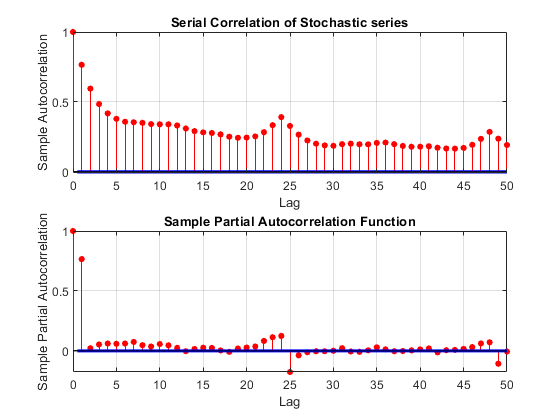

```matlab
figure;
subplot(2,1,1)
autocorr(res,50);
title('Serial Correlation of Stochastic series');
subplot(2,1,2)
parcorr(res,50)
```

## Modeling the Stochastic Component with a seasonal AR model

One could choose to model the random component a mean reverting drift SDE. However, because of the seasonality, we will use an auto-regressive model with seasonal lags. As can be seen from the above plot, there is a strong seasonal correlation on an hourly and daily scale. Therefore we use lags at 1-4 hours and 1-2 days

```matlab
lags = [1 2 3 4 23 24 25 48];
%% Estimate an ARIMAX Model of time series
ARIMAX_ElecPrices = arima('Constant',NaN,'ARLags',lags,'D',0,'MALags',[],'Distribution','Gaussian');
validIndices = find(~any(isnan([X.DA_LMP,X.pred]),2));
preSampleNumber = ARIMAX_ElecPrices.P;
preSampleResponse = X.DA_LMP(validIndices(1:preSampleNumber));
estimateResponse = X.DA_LMP(validIndices(preSampleNumber+1:end));
pred = X.pred(validIndices);
ARIMAX_ElecPrices = estimate(ARIMAX_ElecPrices,estimateResponse,'Y0',preSampleResponse,'X',X.pred,'Display','off');
summarize(ARIMAX_ElecPrices)
```

**ARIMAX(48,0,0) Model (Gaussian Distribution)** Effective Sample Size: 60313 Number of Estimated Parameters: 11 LogLikelihood: -198430 AIC: 396883 BIC: 396982 **Value** **StandardError** **TStatistic** **PValue** **__________** **_____________** **__________** **___________** **Constant** -0.3307 0.04963 -6.6633 2.6776e-11 **AR{1}** 0.98789 0.0011186 883.13 0 **AR{2}** -0.15461 0.0016413 -94.198 0 **AR{3}** 0.00017018 0.0017575 0.09683 0.92286 **AR{4}** 0.0030077 0.0012049 2.4962 0.012552 **AR{23}** 0.12462 0.0011472 108.63 0 **AR{24}** 0.32529 0.0014227 228.65 0 **AR{25}** -0.39366 0.0009921 -396.79 0 **AR{48}** 0.017337 0.00057432 30.188 3.4224e-200 **Beta(1)** 0.097154 0.00063915 152 0 **Variance** 42.188 0.040876 1032.1 0

## Analyze Residuals of Regression for Serial Correlation

The residuals from the regression should now be mostly serially uncorrelated.

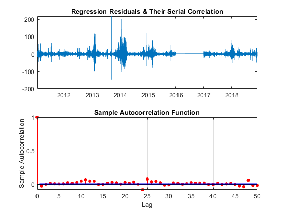

```matlab
res = infer(ARIMAX_ElecPrices,estimateResponse,'Y0',preSampleResponse,'X',pred);
figure;
subplot(2,1,1);
dates = X.Date(validIndices);
plot(dates(preSampleNumber+1:end), res);
title('Regression Residuals & Their Serial Correlation');
subplot(2,1,2);
autocorr(res,50);
```

## Summary of model

The electricity model can now be defined by,

```matlab
elecModel = struct('treemodel', trainedModel, 'reglags', lags, 'arimax', ARIMAX_ElecPrices,'lastDate',T.Date(end),'Freq','hourly')
```

elecModel = struct with fields:

treemodel: [1×1 struct] reglags: [1 2 3 4 23 24 25 48] arimax: [1×1 arima] lastDate: 11/30/2018 Freq: 'hourly'

```matlab
save SavedModels\ElectricityModel -struct elecModel
```

## Simulate model

We can now simulate this model for 2016 and compare the simulated values to the observed data for 2016 since this was not originally tested. We already loaded in the temperaature model, and we can simulate the dry bulb temperature (note that we already put in the AveTemp in T ealier).

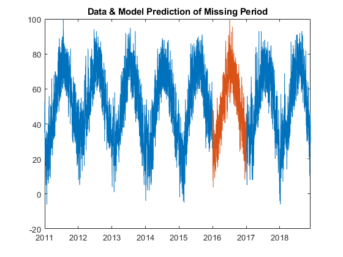

```matlab
Indicies2016 = find(ismissing(T.Dry_Bulb));
preSampleNumber = tempModel.arimax.P;
preSampleIndicies = (Indicies2016(1)-preSampleNumber):Indicies2016(1)-1;
Temp2016= simulate(tempModel.arimax,length(Indicies2016),'Y0',T.Dry_Bulb(preSampleIndicies),'X',T.AveTemp(preSampleIndicies(1):Indicies2016(end)));
figure
plot(T.Date,T.Dry_Bulb, T.Date(Indicies2016), Temp2016)
title('Data & Model Prediction of Missing Period')
```

Now we can simulate the electricity price for 2016 and compare to the original.

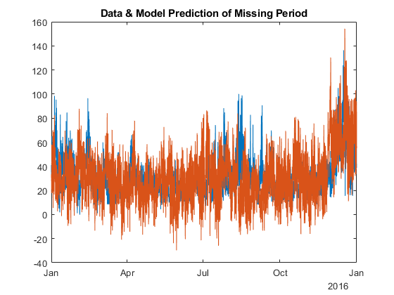

```matlab
T.Dry_Bulb(Indicies2016) = Temp2016;
T.TempDeviation(Indicies2016) = Temp2016 - T.AveTemp(Indicies2016);
T.pred = trainedModel.predictFcn(timetable2table(T));
elecPrices2016= simulate(ARIMAX_ElecPrices,length(Indicies2016),'Y0',T.DA_LMP(preSampleIndicies),'X',T.pred(preSampleIndicies(1):Indicies2016(end)));
figure
plot(T.Date(Indicies2016),T.DA_LMP(Indicies2016), T.Date(Indicies2016), elecPrices2016)
title('Data & Model Prediction of Missing Period')
```